# MidtermCheatsheet

Vikas

3/3/2022

Sample mean $\bar{x} = \frac{1}{n} * \sum_{} x_{i}$

Sample median $\bar{x} = x_{(n+1)/2}$ Odd, $\frac{1}{2}*( x_{n/2} + x_{(n/2)+1})$ Even.

Sample variance $s^2 = \frac{\sum_{}(x_i - \bar{x})^2}{n-1}$

Sample standard deviation $s = \sqrt{s^2}$

Sample range $x_{max}-x_{min}$

Population mean $\mu = \frac{\sum{}X}{N}$

Population variance $\sigma^2 = \frac{\sum_{}(X_i - \mu)^2}{N}$

Population standard deviation $\sigma = \sqrt{\sigma^2}$

$0 \leq z_{-\frac{\alpha}{2}}\leq P(E) \leq z_{\frac{\alpha}{2}}\leq 1$

$Z(Standard Normal Random Varaible) = \frac{x-\bar{x}}{s}\sim \mathcal{N}(0,1)$

$P(a \leq X \leq b) = P(\frac{a-\mu}{\sigma}) \leq Z \leq \frac{b-\mu}{\sigma})$

$Z(CLT) = \frac{X-\mu}{{\sigma}/{\sqrt{n}}} when \ n \to \infty \ and \ Z \sim \mathcal{N}(0,1)$  
Note: (n>30) and $\mu =\bar{x}$ and $\sigma = s\sqrt{n}$ or $\sigma^2 = s^2 n$

When sample size increases, sample mean has a larger probability to close to population mean.

$Z = \frac{(x_1-x_2)-(\mu_1 - \mu_2)}{\sqrt{\sigma_1^2/n_1 + \sigma_2^2/n_2}}$

Important R functions to generate random numbers, pdf (aka pmf), cdf, and quantiles. The prefixes for these functions are:  
- r: random number generation  
- d: probability density function or probability mass function  
- p: cumulative distribution function  
- q: quantiles

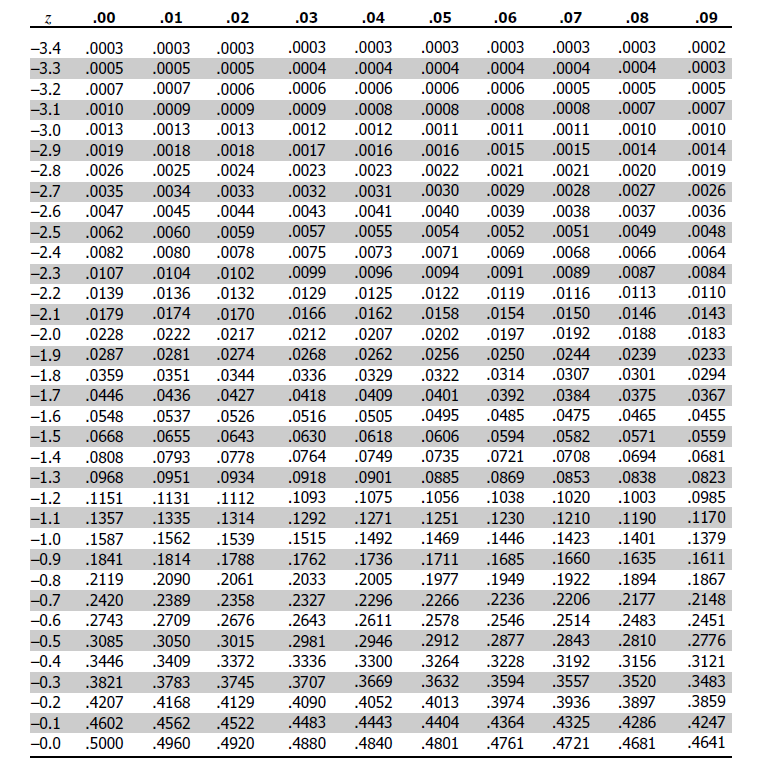

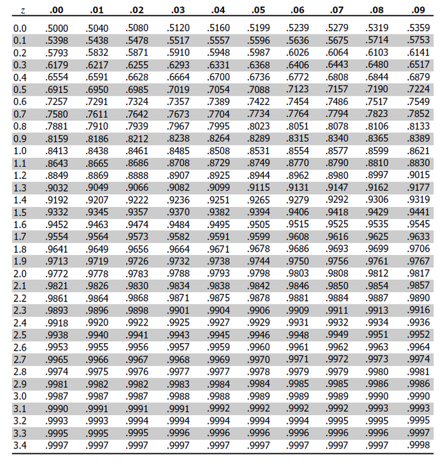